# 3_data_analysis

María Rollan, Cesar Ramos

2023-06-14

# Dataset original

```r
df <- read.csv("../datasets/puntuacionesFA.csv")
```

En este caso las columnas con filas las identifica como character, pero va a ser un problema ya que en este caso no vamos a utilizar esas columnas para analizar nada, cuando queramos analizar esas columnas utilizaremos los subsets que ya hemos generado.

## Correlación entre el número de votos y la nota media de las películas

Vamos a analizar si las películas que mas gente ve son aquellas con mejor nota, esto sería lo lógico ya que la gente recomienda las películas que le gustan por lo tanto estas se verán mas. Por otro lado está el marketing de las películas que puede hacer que películas malas sean muy vistas.

Para esto vamos a utilizar un análisis de correlación.

```r
cor.test(df$votos, df$nota)
```

```
##
##  Pearson's product-moment correlation
##
## data:  df$votos and df$nota
## t = 22.273, df = 1936, p-value < 2.2e-16
## alternative hypothesis: true correlation is not equal to 0
## 95 percent confidence interval:
##  0.4154677 0.4863848
## sample estimates:
##       cor
## 0.4516394
```

En este análisis vemos que, aunque el valor del coeficiente de correlación no es muy elevado (R = 0.45), existe una correlación claramente significativa, con una p < 2.2e-16. Por lo tanto podemos afirmar que existe asociación positiva significativa entre la gente que ve una película y la valoración que tiene. No podemos saber si cuanto mejor es una película más gente la ve, o si cuanto más gente ve una película mejor la perciben, aunque lo esperable es lo primero.

## Correlación entre la nota media de la película y la nota media del usuario

Vamos a analizar si el usuario vota similar al resto de usuario analizando la correlación entre la nota media de la pelicula y el voto del usuario

```r
cor.test(df$votacion, df$nota)
```

```
##
##  Pearson's product-moment correlation
##
## data:  df$votacion and df$nota
## t = 39.965, df = 1936, p-value < 2.2e-16
## alternative hypothesis: true correlation is not equal to 0
## 95 percent confidence interval:
##  0.6472038 0.6960434
## sample estimates:
##       cor
## 0.6723547
```

En este caso vemos que la correlación es significativa, como en el caso anterior, pero además es bastante más potente que en el caso anterior, por tanto el usuario vota bastante similar a la nota media de las películas. Podemos ver esto representado en un plot.

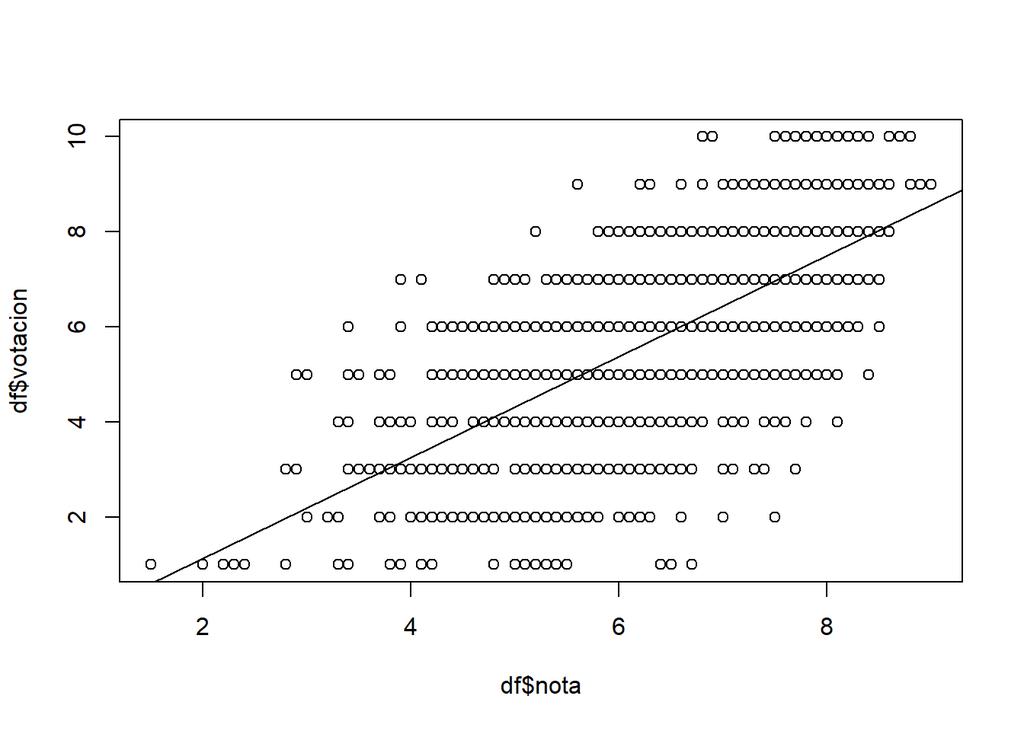

```r
plot(df$nota, df$votacion)
abline(lm(df$votacion~df$nota))
```

En el gráfico se puede observar perfectamente como a medida que aumenta la nota media aumenta la puntuación del usuario.

# Directores

Ahora vamos a analizar los directores de las películas votadas. Esto puede ser util para descubrir cuales son los directores mejor valorados por el usuario, para que en el futuro pueda buscar películas que le puedan gustar en base a los directores con mejor nota.

```r
direct <- read.csv("../datasets/directores_subset.csv")
```

## Directores más votados

Vamos a escoger los directores con más de 10 películas votadas y vamos a trabajar con ellos, para tener suficiente N.

```r
direct_10 <-as.data.frame(summary(as.factor(direct$directores)))
colnames(direct_10) <- "n"
direct_10 <- cbind(rownames(direct_10), direct_10)
colnames(direct_10) <- c("director", "n")
rownames(direct_10) <- 1:nrow(direct_10)

direct_10 <- direct_10[which(direct_10$n > 10 & direct_10$director != "(Other)"),]
direct_10
```

```
##              director  n
## 1    Steven Spielberg 26
## 2     Pedro Almodóvar 20
## 3          Tim Burton 18
## 4    Alfred Hitchcock 16
## 5     Martin Scorsese 14
## 6    David Cronenberg 13
## 7      Don Hertzfeldt 13
## 8  Álex de la Iglesia 12
## 9      Clint Eastwood 12
## 10        Woody Allen 12
## 11  Christopher Nolan 11
## 12        David Lynch 11
## 13 M. Night Shyamalan 11
## 14     Roman Polanski 11
## 15    Stanley Kubrick 11
```

Vamos a representar estos resultados gráficamente

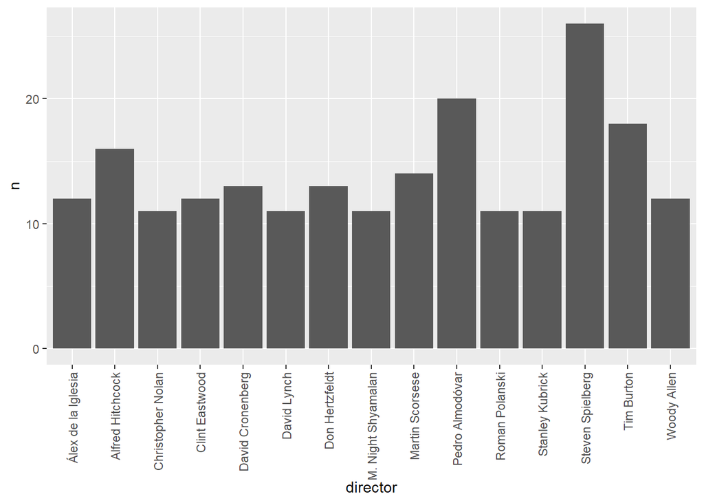

```r
library(ggplot2)
ggplot(direct_10[order(direct_10$n),], aes(x=director, y=n)) +
  geom_bar(stat = "identity")+
  theme(axis.text.x=element_text(angle=90,hjust=1,vjust=0.5))
```

Vemos que el director más votado es Steven Spielberg, seguido de Pedro almodovar y de Tim Burton. Ahora vamos a ver como se comportan las notas de estos directores mediante un boxplot.

## Votación del usuario por director

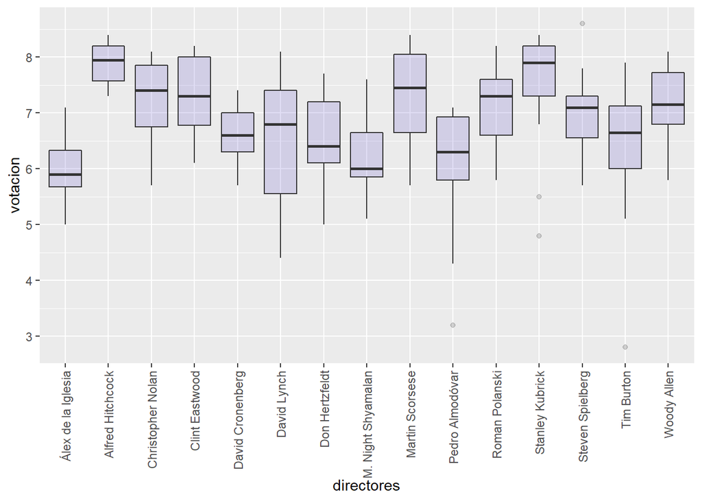

```r
box <- direct[which(direct$directores %in% direct_10$director),]
ggplot(box, aes(x=directores, y=votacion)) +
    geom_boxplot(fill="slateblue", alpha=0.2) +
    theme(axis.text.x=element_text(angle=90,hjust=1,vjust=0.5))
```

Aqui podemos ver como son valorados los directores más votados. Parece que Hitchcock es el director mejor valorado. También está muy bien valorado Stanley Kubrick. Clint Eastwood, Cristopher Nolan y Martin Scorsese también estan bastante bien valorados pero por detras. Por otro lado vemos directores que tienen notas muy irregulares, por ejemplo el rango de notas de David Lynch es muy amplio, y también lo es el de Martin Scorsese.

## Diferencias entre votaciones por director

Ahora podemos estudiar entre los dos directores con aparentemente mejores notas si hay diferencias significativas entre ellos. Primero vamos estudiar si existe normalidad de los datos.

```r
library(nortest)
lillie.test(direct$votacion[direct$directores == "Alfred Hitchcock"])
```

```
##
##  Lilliefors (Kolmogorov-Smirnov) normality test
##
## data:  direct$votacion[direct$directores == "Alfred Hitchcock"]
## D = 0.22703, p-value = 0.02694
```

```r
lillie.test(direct$votacion[direct$directores == "Stanley Kubrick"])
```

```
##
##  Lilliefors (Kolmogorov-Smirnov) normality test
##
## data:  direct$votacion[direct$directores == "Stanley Kubrick"]
## D = 0.34816, p-value = 0.0005436
```

Parece que los datos no son normales, además no tenemos una n suficiente como para asumir la teoría del límite central, por lo que en vez de estudiar la homocedastidad podemos pasar directamente a utilizar un test no paramétrico. Aun así vamos a demostrar como se calcularía la homocedastidad.

```r
var.test(direct$votacion[direct$directores== "Alfred Hitchcock"], direct$votacion[direct$directores== "Stanley Kubrick"])
```

```
##
##  F test to compare two variances
##
## data:  direct$votacion[direct$directores == "Alfred Hitchcock"] and direct$votacion[direct$directores == "Stanley Kubrick"]
## F = 0.08446, num df = 15, denom df = 10, p-value = 4.081e-05
## alternative hypothesis: true ratio of variances is not equal to 1
## 95 percent confidence interval:
##  0.02398284 0.25846343
## sample estimates:
## ratio of variances
##         0.08445974
```

```r
wilcox.test(direct$votacion[direct$directores== "Alfred Hitchcock"], direct$votacion[direct$directores== "Stanley Kubrick"])
```

```
##
##  Wilcoxon rank sum test with continuity correction
##
## data:  direct$votacion[direct$directores == "Alfred Hitchcock"] and direct$votacion[direct$directores == "Stanley Kubrick"]
## W = 92, p-value = 0.8609
## alternative hypothesis: true location shift is not equal to 0
```

Parece que no hay diferencias significativas entre estos dos directores.

Podemos analizar también si hay diferencias significativas entre todos los directores que hemos estudiado.

```r
lillie.test(box$votacion)
```

```
##
##  Lilliefors (Kolmogorov-Smirnov) normality test
##
## data:  box$votacion
## D = 0.061894, p-value = 0.04797
```

Vemos que los datos siguen sin ser normales, por lo tanto vamos a aplicar un test no paramétrico para más de dos grupos (Kruskal Wallis)

```r
kruskal.test(box$votacion ~box$directores)
```

```
##
##  Kruskal-Wallis rank sum test
##
## data:  box$votacion by box$directores
## Kruskal-Wallis chi-squared = 72.051, df = 14, p-value = 8.187e-10
```

Parece que entre estos directores si hay diferencias, pero este test nos habla de diferencias globales, pero no sabemos entre que directores hay diferencias, para eso tendremos que utilizar un test post-hoc, que nos ajuste la p. Para ello vamos a utilizar Wilcoxon test con corrección de bonferroni.

```r
pairwise.wilcox.test(box$votacion,box$directores, p.adjust.method = "bonferroni")
```

```
##
##  Pairwise comparisons using Wilcoxon rank sum test with continuity correction
##
## data:  box$votacion and box$directores
##
##                    Álex de la Iglesia Alfred Hitchcock Christopher Nolan
## Alfred Hitchcock   0.00090            -                -
## Christopher Nolan  0.19214            1.00000          -
## Clint Eastwood     0.06782            1.00000          1.00000
## David Cronenberg   1.00000            0.00075          1.00000
## David Lynch        1.00000            0.07144          1.00000
## Don Hertzfeldt     1.00000            0.00333          1.00000
## M. Night Shyamalan 1.00000            0.00413          1.00000
## Martin Scorsese    0.05804            1.00000          1.00000
## Pedro Almodóvar    1.00000            3.7e-05          0.39479
## Roman Polanski     0.32451            0.65583          1.00000
## Stanley Kubrick    1.00000            1.00000          1.00000
## Steven Spielberg   0.03258            0.00213          1.00000
## Tim Burton         1.00000            0.00238          1.00000
## Woody Allen        0.36596            0.46442          1.00000
##                    Clint Eastwood David Cronenberg David Lynch Don Hertzfeldt
## Alfred Hitchcock   -              -                -           -
## Christopher Nolan  -              -                -           -
## Clint Eastwood     -              -                -           -
## David Cronenberg   1.00000        -                -           -
## David Lynch        1.00000        1.00000          -           -
## Don Hertzfeldt     1.00000        1.00000          1.00000     -
## M. Night Shyamalan 0.29421        1.00000          1.00000     1.00000
## Martin Scorsese    1.00000        1.00000          1.00000     1.00000
## Pedro Almodóvar    0.16589        1.00000          1.00000     1.00000
## Roman Polanski     1.00000        1.00000          1.00000     1.00000
## Stanley Kubrick    1.00000        1.00000          1.00000     1.00000
## Steven Spielberg   1.00000        1.00000          1.00000     1.00000
## Tim Burton         1.00000        1.00000          1.00000     1.00000
## Woody Allen        1.00000        1.00000          1.00000     1.00000
##                    M. Night Shyamalan Martin Scorsese Pedro Almodóvar
## Alfred Hitchcock   -                  -               -
## Christopher Nolan  -                  -               -
## Clint Eastwood     -                  -               -
## David Cronenberg   -                  -               -
```

[output cut: 12 more lines]

```
## Christopher Nolan  -              -               -                -
## Clint Eastwood     -              -               -                -
## David Cronenberg   -              -               -                -
## David Lynch        -              -               -                -
## Don Hertzfeldt     -              -               -                -
## M. Night Shyamalan -              -               -                -
## Martin Scorsese    -              -               -                -
## Pedro Almodóvar    -              -               -                -
## Roman Polanski     -              -               -                -
## Stanley Kubrick    1.00000        -               -                -
## Steven Spielberg   1.00000        1.00000         -                -
## Tim Burton         1.00000        1.00000         1.00000          -
## Woody Allen        1.00000        1.00000         1.00000          1.00000
##
## P value adjustment method: bonferroni
```

Aqui se nos presenta una tabla con la comparación de directores uno por uno pero con la p ajustada por el número de comparaciones. Podemos ver entonces que Alfred Hitchcock tiene una puntuación media por el usuario significativamente superior a Alex de la Iglesia, David Cronenberg, Don Hertzfeldt, Pedro Almodovar, Steven Spielberg y Tim Burton.

Asi podemos ver todo el resto de comparaciones, pero hay que tener en cuenta que muchos de estos directores tienen muy pocas películas votadas, por lo que es normal que los directores con más películas votadas tiendan a mostrar diferencias más significativas que los directores con menos películas votadas. Por ejemplo, Stanley Kubrick que tiene menos películas votadas, no muestra diferencias significativas con ningun otro director, a pesar de ser de los aparentemente mejor votados en el boxplot.

## Diferencias entre paises por director

Vamos a comprobar si cada director se asocia a un pais, lo cual sería lo normal, aunque es verdad que directores de un pais pueden dirigir en otro.

Para ello primero vamos a hacer una tabla y luego vamos a aplicar el test chi cuadrado para comparar dos variables cualitativas

```r
prop.table(table(box$directores, box$pais), margin = 1)
```

```
##
##                          Canadá     España Estados Unidos    Francia    Polonia
##   Álex de la Iglesia 0.00000000 1.00000000     0.00000000 0.00000000 0.00000000
##   Alfred Hitchcock   0.00000000 0.00000000     0.93750000 0.00000000 0.00000000
##   Christopher Nolan  0.00000000 0.00000000     0.72727273 0.00000000 0.00000000
##   Clint Eastwood     0.00000000 0.00000000     1.00000000 0.00000000 0.00000000
##   David Cronenberg   0.61538462 0.00000000     0.23076923 0.00000000 0.00000000
##   David Lynch        0.00000000 0.00000000     1.00000000 0.00000000 0.00000000
##   Don Hertzfeldt     0.00000000 0.00000000     1.00000000 0.00000000 0.00000000
##   M. Night Shyamalan 0.00000000 0.00000000     1.00000000 0.00000000 0.00000000
##   Martin Scorsese    0.00000000 0.07142857     0.92857143 0.00000000 0.00000000
##   Pedro Almodóvar    0.00000000 1.00000000     0.00000000 0.00000000 0.00000000
##   Roman Polanski     0.00000000 0.00000000     0.18181818 0.36363636 0.09090909
##   Stanley Kubrick    0.00000000 0.00000000     0.45454545 0.00000000 0.00000000
##   Steven Spielberg   0.00000000 0.00000000     1.00000000 0.00000000 0.00000000
##   Tim Burton         0.00000000 0.00000000     1.00000000 0.00000000 0.00000000
##   Woody Allen        0.00000000 0.00000000     0.83333333 0.00000000 0.00000000
##
##                      Reino Unido
##   Álex de la Iglesia  0.00000000
##   Alfred Hitchcock    0.06250000
##   Christopher Nolan   0.27272727
##   Clint Eastwood      0.00000000
##   David Cronenberg    0.15384615
##   David Lynch         0.00000000
##   Don Hertzfeldt      0.00000000
##   M. Night Shyamalan  0.00000000
##   Martin Scorsese     0.00000000
##   Pedro Almodóvar     0.00000000
##   Roman Polanski      0.36363636
##   Stanley Kubrick     0.54545455
##   Steven Spielberg    0.00000000
##   Tim Burton          0.00000000
##   Woody Allen         0.16666667
```

```r
chisq.test(box$directores, box$pais)
```

```
##
##  Pearson's Chi-squared test
##
## data:  box$directores and box$pais
## X-squared = 486.29, df = 70, p-value < 2.2e-16
```

En la tabla podemos ver donde ha dirigido mayoritariamente cada director. Por ejemplo vemos que David Cronenberg ha dirigido la mayoría de sus películas en cadadá, pero también ha dirigido en Estados Unidos y en Reino Unido. Pedro Almodovar por otro lado ha dirigido el 100% de sus películas en España. Roman Polanski es el director que ha dirigido en más paises diferentes: Estados Unidos, Francia, Polonia y Reino Unido.

El test de chi cuadrado nos demuestra que hay asociación entre paises y directores significativas, el problema es que no sabemos cuales son significativas, para ello tenemos que hacer un análisis post-hoc.

```r
library(devtools)
results <- chisq.posthoc.test::chisq.posthoc.test(table(box$directores, box$pais), method = "bonferroni")
results[results$Value == "p values",]
```

```
##             Dimension    Value Canadá España Estados Unidos Francia  Polonia
## 2  Álex de la Iglesia p values      1      0       0.000006       1 1.000000
## 4    Alfred Hitchcock p values      1      1       1.000000       1 1.000000
## 6   Christopher Nolan p values      1      1       1.000000       1 1.000000
## 8      Clint Eastwood p values      1      1       1.000000       1 1.000000
## 10   David Cronenberg p values      0      1       0.014551       1 1.000000
## 12        David Lynch p values      1      1       1.000000       1 1.000000
## 14     Don Hertzfeldt p values      1      1       1.000000       1 1.000000
## 16 M. Night Shyamalan p values      1      1       1.000000       1 1.000000
## 18    Martin Scorsese p values      1      1       1.000000       1 1.000000
## 20    Pedro Almodóvar p values      1      0       0.000000       1 1.000000
## 22     Roman Polanski p values      1      1       0.012233       0 0.001727
## 24    Stanley Kubrick p values      1      1       1.000000       1 1.000000
## 26   Steven Spielberg p values      1      1       0.029405       1 1.000000
## 28         Tim Burton p values      1      1       0.307974       1 1.000000
```

[output cut: 17 more lines]

# Conclusiones

Podriamos hacer estos mismos análisis para todas las columnas que quisieramos. Con este analisis podemos estudiar donde se concentran los gustos de un usuario en cuanto a paises, directores, guionistas, fotógrafos, géneros… Y esto puede ser de gran utilidad para buscar futuras películas que puedan gustar al usuario. Por otro lado se pueden generar gráficas para que el usuario tenga un registro de sus películas votadas según todas las características recogidas; es verdad que Filmaffinity aporta ciertas estadísticas, pero con este dataset las estadísticas y gráficas que se pueden generar son mucho mayores.

Ahora mismo con lo que hemos estudiado, que no es ni una décima parte de lo que podríamos estudiar, podemos saber que a este usuario le gusta mucho Stanley Kubrick y Alfred Hitchcock, por lo que podrá buscar películas de estos directores para ver, con una certeza alta de que estas películas le gustarán.